# Group A — Yogurt & the Vaginal Microbiome

Does eating yogurt help *L. crispatus* recover after antibiotics?

Group A

2026-06-05

## Our question

> **Does eating yogurt help *Lactobacillus crispatus* — the “good” vaginal bacterium — recover after antibiotic treatment?**
- Antibiotics kill bacteria indiscriminately, disrupting the vaginal microbiome
- Yogurt contains live bacteria — could it help *L. crispatus* bounce back?
- **51 participants** assigned to either **yogurt** or **unchanged diet**
- Sampled at **baseline** (before study) and **after antibiotic** treatment

## Who are the participants?

| **Characteristic** | **Overall** N = 51<sup>1</sup> | **unchanged_diet** N = 25<sup>1</sup> | **yogurt** N = 26<sup>1</sup> | **p-value**<sup>2</sup> |
| --- | --- | --- | --- | --- |
| days_since_last_sex | 5 (3, 11) | 6 (3, 10) | 5 (3, 11) | 0.8 |
| birth_control |  |  |  | 0.017 |
| Depoprovera | 25 (49%) | 8 (32%) | 17 (65%) |  |
| no hormonal birth control | 26 (51%) | 17 (68%) | 9 (35%) |  |
| age | 30.7 (3.3) | 30.4 (3.3) | 31.0 (3.3) | 0.5 |
| education |  |  |  | 0.8 |
| grade 10-12, matriculated | 10 (20%) | 6 (24%) | 4 (15%) |  |
| grade 10-12, not matriculated | 21 (41%) | 9 (36%) | 12 (46%) |  |
| less than grade 9 | 9 (18%) | 4 (16%) | 5 (19%) |  |
| post-secondary | 11 (22%) | 6 (24%) | 5 (19%) |  |

<sup>1</sup> Median (Q1, Q3); n (%); Mean (SD)  
<sup>2</sup> Wilcoxon rank sum test; Pearson’s Chi-squared test; Welch Two Sample t-test; Fisher’s exact test

### Key takeaways

- **51 women** — 25 unchanged diet, 26 yogurt
- Age is balanced (≈31 in both groups, p = 0.55)
- ⚠️ **Birth control is imbalanced** — 65% of yogurt group uses Depoprovera vs. 32% of unchanged diet

## What did we find? *L. crispatus* recovery

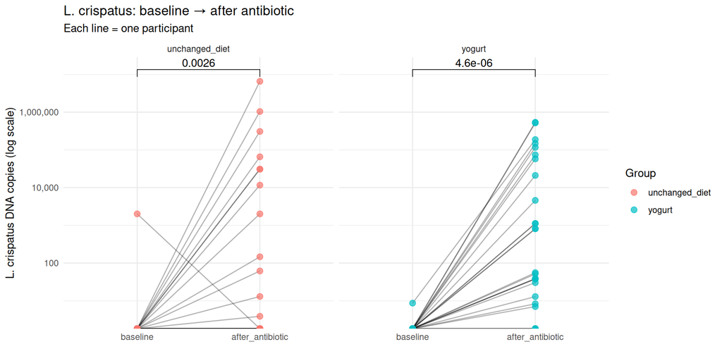

## What the figure shows

| Group | % with detectable L. crispatus |
| --- | --- |
| unchanged_diet | 48 |
| yogurt | 85 |

| Time point | Yogurt group | Unchanged diet |
| --- | --- | --- |
| **Baseline** | 96% undetected | 96% undetected |
| **After antibiotic** | **85% detected** | **48% detected** |

## Limitations

> **What could go wrong with our conclusion?**
1. **Birth control imbalance** — 17/26 yogurt participants use Depoprovera vs. 8/25 in unchanged diet. Depoprovera affects hormones and could independently influence the microbiome
2. **No placebo** — participants knew their group
3. **Small sample** — 51 participants; a few extreme values can shift results
4. **No adjustment** — we haven’t controlled for confounders yet
5. **Cytokines mostly unmeasurable** — several inflammatory markers were below detection limits, so we couldn’t check immune response

## If we had another week

1. **Adjust for Depoprovera** in the model — does the yogurt effect hold?
2. **Check *L. iners*** — does yogurt shift the *L. crispatus* / *L. iners* ratio?
3. **Identify the 9 extreme samples** with very high bacterial load — are they from one group?
4. **Build a simple linear model** predicting *L. crispatus* from group + age + birth control

## What we learned

> **From the data** - Log scales aren’t optional when data spans 4+ orders of magnitude - Zeros aren’t missing — 65% of samples had zero *L. crispatus*, which is real biology - “Out of range” cytokine measurements (IL-10, IFN-Y, TNFa) tell us the assay may not be sensitive enough for vaginal samples

> **From the process** - Making one plot three times teaches more than making three different plots once - Always verify: does the test match the distribution? (Skewed data → Wilcoxon) - A clean dataset with no missing values still needs careful interpretation

## Thank you

**Any questions?**

Slides built with Quarto + revealjs

Code and data: `data/group_a_yogurt/` and `group_project/group_a/`